# Taller_3

John Esteban

2024-04-27

# Introduccion

La inversión más importante para la mayoría de las personas es tener casa propia, y esta es una de las fuentes más comunes en la acumulación de capital. Por esto, conocer cuáles son los elementos que determinan el valor de este bien puede servir de guía para el proceso de planificación financiera.

El modelo que mejor rendimiento ha presentado para la predicción de los precios de las viviendas es el Random Forest. El trabajo desarrollado por Cueto (2022), utilizando solo características de la vivienda en cinco modelos, entre ellos redes neuronales y modelos basados en árboles, encuentra que el que tiene mejor rendimiento es el Random Forest. De la misma forma, el trabajo de Choy and Ho (2023), en el que además de las características de la vivienda se utiliza la variable de la distancia al transporte, concluye que el mejor modelo es el Random Forest. Alfaro-Navarro et al. (2020), Alzate (2019) y Giraldo (n.d.) también encuentran que el Random Forest es el mejor modelo.

El propósito de este artículo es realizar la predicción de precios de vivienda en Bogotá. En este proceso, se utilizan tanto variables propias de la vivienda como variables que describen el entorno donde está ubicada. Además, se hace uso extensivo de técnicas de procesamiento de lenguaje natural para aprovechar las descripciones de las viviendas.

# Datos

## **Agregación de las Nuevas Variables**

Para modelar el precio de las viviendas en Bogotá, se cuenta con diversas características propias del hogar. En primer lugar, tenemos el precio de la vivienda, que es la variable que se va a modelar. Luego, disponemos de algunos atributos esenciales para iniciar el proceso de modelación, tales como el área de la vivienda, el número de habitaciones para dormir y el número de baños. También se puede caracterizar el tipo de vivienda, diferenciando si es una casa o un apartamento. Además, se tiene a disposición la descripción de la vivienda, de donde se pueden extraer datos que ayuden a describir mejor la propiedad. A partir de esta descripción, se ha agregado el número de habitaciones que tiene la vivienda.

Para conocer mejor el contexto en el que se ubica la vivienda, se creó la variable “estrato” a partir de la información del DANE. En primer lugar, se descargó la cartografía del Marco Geoestadístico Nacional del DANE y el Censo 2018 a nivel de manzana. Luego, se hizo un join espacial entre cada uno de los inmuebles y el Marco Geoestadístico Nacional para identificar la manzana de cada una de las viviendas. Posteriormente, con el código de manzana, se realizó un join con el Censo 2018 para identificar el estrato predominante.

La percepción de seguridad también es un aspecto clave para determinar la disposición a pagar por una vivienda. Se espera que, si hay mayor seguridad, el precio de la vivienda sea mayor. Para medir este fenómeno, se incluyeron una serie de variables relevantes. Con las cifras oficiales de la alcaldía, se obtuvo información geolocalizada de hurtos a personas y viviendas. Esta información solo está disponible a nivel de localidades y no georreferenciada de manera similar a la base de datos. Por ello, se utilizó la distancia para integrar la información de hurtos más cercanos. Además, a través de la información de Google, se calculó la distancia entre las viviendas y las estaciones de policía.

En resumen, para modelar el precio de las viviendas en Bogotá, se consideran variables propias de la vivienda, como el área, el número de habitaciones, el número de baños y el tipo de vivienda, además de variables contextuales como el estrato y la percepción de seguridad. Estas últimas se obtienen mediante un join espacial con datos del DANE y la alcaldía, así como a través de la distancia a estaciones de policía y zonas con mayor incidencia de hurtos. Este enfoque integral permite una mejor descripción y predicción del precio de las viviendas.

## Analisis descriptivo de los datos

### Precio de la vivienda

El objetivo de este artículo es predecir el precio de las viviendas en la ciudad de Bogotá. Esta variable está medida a lo largo de tres años distintos, lo que en términos reales no representa lo mismo debido a la inflación. Inicialmente, se intentó ajustar los precios a términos reales deflactándolos por la inflación, pero los resultados no fueron coherentes. Por ello, se optó por utilizar efectos fijos, lo que mejoró la predicción considerablemente.

Teniendo esto en cuenta, se observa que el precio de entrada para comprar una vivienda en Bogotá, tomando como referencia esta base de datos, es de 300 millones de pesos, con un máximo de 1650 millones y un precio promedio de aproximadamente 650 millones. En términos de precios de vivienda, Bogotá se encuentra por debajo del promedio nacional. Según el Índice de Precios de Vivienda del DANE, el índice de precios en Bogotá es de 126 puntos, mientras que el promedio nacional es de 130 puntos. Además, el aumento de precios durante estos tres años ha sido moderado, con un incremento promedio del 8%.

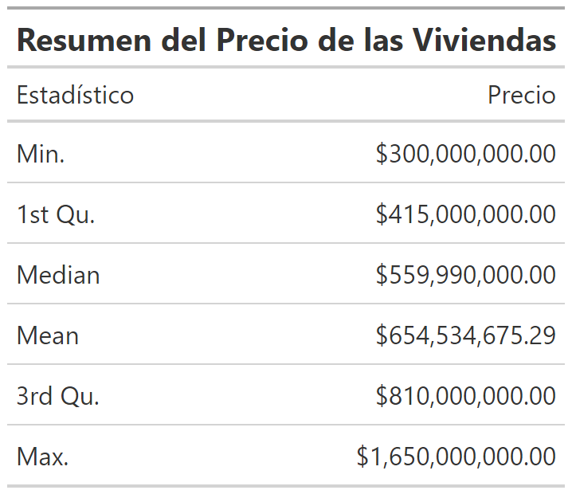

### Caracteristicas del hogar

En primer lugar, vamos a analizar cómo se relacionan las principales variables del hogar con el precio de venta. Para este análisis, tomaremos en cuenta el número de habitaciones, el número de baños, el número de alcobas, el tipo de propiedad, el estrato y el piso donde se encuentra ubicada la vivienda. Inicialmente, imputaremos de forma sencilla las variables que tienen valores NA y luego procederemos con un análisis descriptivo bivariado.

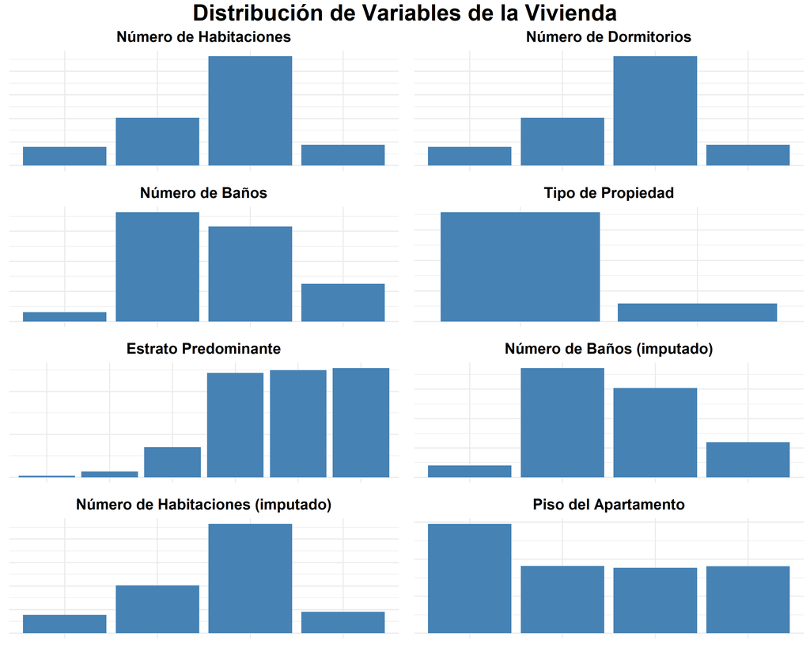

Es interesante observar que la cantidad de habitaciones más común tanto para las habitaciones en general como para las habitaciones para dormir es 3. Además, la cantidad de baños tiende a ser similar, lo que podría explicarse por el hecho de que la mayoría de las viviendas en venta son apartamentos. Esta distribución de baños se concentra principalmente en 2 y 3, lo que sugiere una preferencia por una distribución equilibrada en los espacios de descanso y aseo.

Es importante resaltar que la muestra de datos que tenemos disponible muestra una predominancia de apartamentos ubicados en zonas de Estrato 4, 5 y 6. Esto puede indicar una tendencia hacia viviendas de mayor estatus socioeconómico en la muestra analizada.

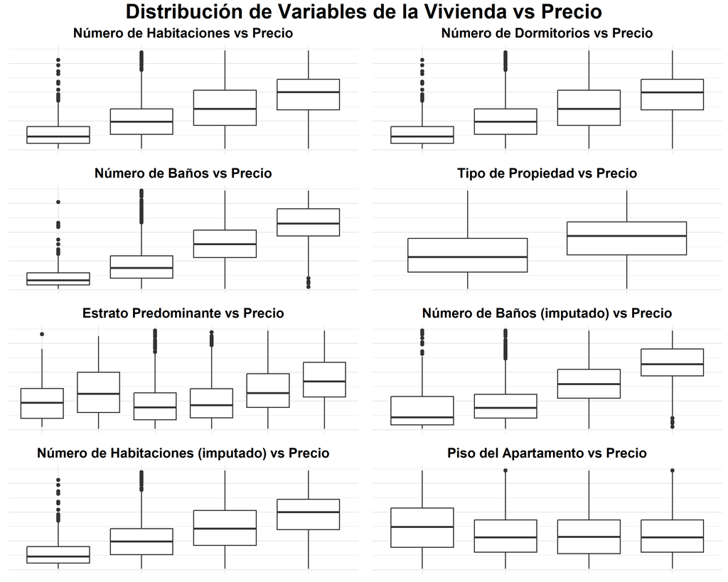

Es interesante observar que al analizar la relación entre las características de las viviendas y el logaritmo del precio de las viviendas, se encuentran relaciones estadísticas significativas con el número de baños, el número de habitaciones, el tipo de vivienda y el estrato socioeconómico.

Estos hallazgos son consistentes con lo que se ha observado en la literatura previa, donde se muestra que a medida que una vivienda tiene más habitaciones, su precio tiende a aumentar, lo mismo ocurre con la cantidad de baños. Además, para esta muestra en particular, se observa que el tipo de vivienda más costoso son las casas, aunque se debe tener en cuenta que hay pocos registros para este tipo de vivienda, lo que podría sesgar los resultados.

Por último, se nota que a medida que aumenta el estrato socioeconómico, el precio promedio de la vivienda tiende a aumentar, especialmente en los estratos 4 al 6, donde se tienen más datos disponibles. Esto sugiere una relación positiva entre el estrato y el precio de la vivienda en esta muestra analizada.

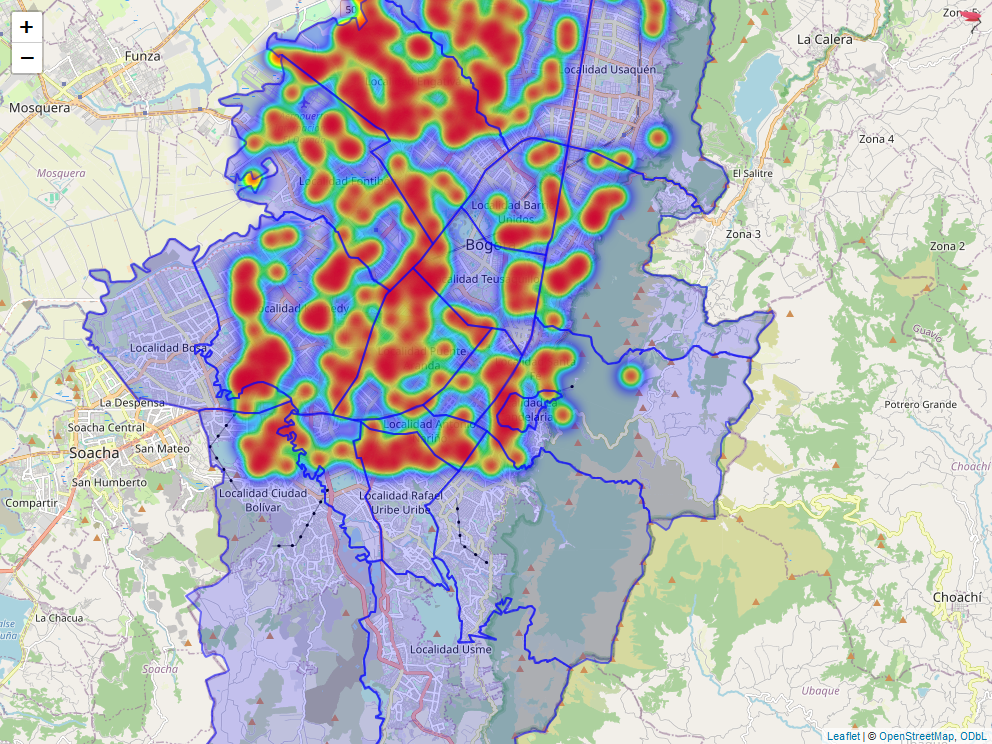